# Incorporating New Evidence and Uncertainty

Backwards Conversion, Solving for PSA Parameters and Copula-Based PSA Sampling

## Learning Objectives

1. Back-convert an existing transition probability matrix to incorporate new health states, strategies, and evidence.
2. Solve for probabilisitic sensitivity analysis (PSA) distribution parameters.
3. Sample correlated PSA distributions using copulas.

## 1. Backwards Conversion

- Lectures 2 and 3 emphasized the importance of the transition rate matrix as the central “hub” of a Markov model.
- If starting a model from scratch, can simply define or estimate rates, and use them to construct the rate matrix.

## 1. Backwards Conversion

- What if we have a model that is already defined in terms of a transition probability matrix?
- How can we convert back to a rate matrix to add new health states, transition states, accumulators, etc. as needed?
- Also useful if we want to keep everything the same, but change the model time step (e.g., see Chhatwal, Jayasuriya, and Elbasha (2016))

## 1. Backwards Conversion

- We will next show you several ways to work backwards.
- Boils down to solving for the continuous “generator matrix” for the observed transition probability matrix.

## A Word of Warning

- As you’ll see, it’s not always going to work perfectly.
- If a transition probability matrix is defined incorrectly (e.g., no jumpover probabilities), the generator matrix may not exist.
- Identifiability is a more general issue, however.

## Working Example: HIV Model

Transition probability matrix:

```
        Healthy LowCD4  AIDS Death
Healthy   0.721  0.202 0.067 0.010
LowCD4    0.000  0.581 0.407 0.012
AIDS      0.000  0.000 0.750 0.250
Death     0.000  0.000 0.000 1.000
```

- From ‘*Decision Modelling for Health Economic Evaluation*’ by Briggs, Claxton, Sculpher.

## A. Matrix Logarithm of P

- In mathematical terms, the generator matrix is the matrix logarithm of the transition probability matrix.
- A matrix has a logarithm *if and only if* if it is invertible.

## A. Matrix Logarithm of P

- In mathematical terms, the generator matrix is the matrix logarithm of the transition probability matrix.
- A matrix has a logarithm *if and only if* if it is invertible.

$$R = \log P$$

## A. Matrix Logarithm of P

- The $\log$ can be found using spectral or eigenvalue decomposition.
- If $V$ is a matrix where equal column is an eigenvector of $T_{prob}$, then

## A. Matrix Logarithm of P

- The $\log$ can be found using spectral or eigenvalue decomposition.
- If $V$ is a matrix where equal column is an eigenvector of $T_{prob}$, then

$$A' = V^{-1} A V$$

## A. Matrix Logarithm of P

- The $\log$ can be found using spectral or eigenvalue decomposition.
- If $V$ is a matrix where equal column is an eigenvector of $T_{prob}$, then

$$A' = V^{-1} A V$$

$$\log P = V (\log A') V^{-1}$$

## A. Matrix Logarithm of P

```r
V  <- eigen(mP)$vectors
iV <- solve(V)
Ap <- iV %*% mP %*% V
lAp <- diag(log(diag(Ap)), nrow(Ap), ncol(Ap))
R  <- V %*% lAp %*% iV
R[abs(R) < 1e-6 ] <- 0
dimnames(R) = dimnames(mP)
round(R,3)
```

## A. Matrix Logarithm of P

```r
V  <- eigen(mP)$vectors
iV <- solve(V)
Ap <- iV %*% mP %*% V
lAp <- diag(log(diag(Ap)), nrow(Ap), ncol(Ap))
R  <- V %*% lAp %*% iV
R[abs(R) < 1e-6 ] <- 0
dimnames(R) = dimnames(mP)
round(R,3)
```

```
        Healthy LowCD4   AIDS  Death
Healthy  -0.327  0.311  0.002  0.013
LowCD4    0.000 -0.543  0.615 -0.072
AIDS      0.000  0.000 -0.288  0.288
Death     0.000  0.000  0.000  0.000
```

## A. Matrix Logarithm of P

```
        Healthy LowCD4   AIDS  Death
Healthy  -0.327  0.311  0.002  0.013
LowCD4    0.000 -0.543  0.615 -0.072
AIDS      0.000  0.000 -0.288  0.288
Death     0.000  0.000  0.000  0.000
```

- Note there is a negative rate from LowCD4 -> Death!
- This is a transition from Death -> LowCD4 and should be moved to the other side of the matrix.

## A. Matrix Logarithm of P

```
        Healthy LowCD4   AIDS  Death
Healthy  -0.327  0.311  0.002  0.013
LowCD4    0.000 -0.543  0.615 -0.072
AIDS      0.000  0.000 -0.288  0.288
Death     0.000  0.000  0.000  0.000
```

- The negative rate implies an identifiable issue.
- Note rates from Healthy->AIDS, Healthy->Death are relatively small, implying these are from statistical noise in observation.

## A. Matrix Logarithm of P

- `expm::logm` Higham (2008) method returns same as eigenvalue method.
- Tweaking rates to get a proper model is ad-hoc and difficult.

## A. Matrix Logarithm of P

- `expm::logm` Higham (2008) method returns same as eigenvalue method.
- Tweaking rates to get a proper model is ad-hoc and difficult.

```r
R = expm::logm(mP)
```

```
        Healthy LowCD4   AIDS  Death
Healthy  -0.327  0.311  0.002  0.013
LowCD4    0.000 -0.543  0.615 -0.072
AIDS      0.000  0.000 -0.288  0.288
Death     0.000  0.000  0.000  0.000
```

## B. Multi-State Model Based Approach

- Imposition of structural assumptions and fitting to raw data can result in better rate estimates.
- We could assume that a patient with HIV at this point in time only gets sicker and external causes of death are negligible. Healthy->LowCD4->AIDS->Death constrains model.
- We use the reported data from the original model at year 1
- MSM Method: https://chjackson.github.io/msm/msmcourse/

## B. Multi-State Model Based Approach

Steps:

1. Run the original model for a single cycle.
2. Construct psuedo-data from the resulting trace based on a cohort with reasonable size (e.g., 1,000 patients)
3. Estimate transition hazards in the pseudo-data based on a multistate model.
4. Use the estimated transition hazards to construct the rate matrix.

## 1. Run the original model for a single cycle.

```r
tr0 <-
  c("Healthy" = 1000,"LowCD4" = 0, "AIDS" = 0, "Death" = 0)
tr1 <-
  tr0 %*% mP

tr <-
    rbind.data.frame(tr0, tr1) %>%
    mutate(cycle = c(0, 1)) %>%
    select(cycle,everything())
tr
```

```
  cycle Healthy LowCD4 AIDS Death
1     0    1000      0    0     0
2     1     721    202   67    10
```

## 2. Construct psuedo-data

```r
tr <-
    rbind.data.frame(tr0, tr1) %>%
    mutate(cycle = c(0, 1)) %>%
    gather(state,count,-cycle) %>%
    mutate(count = round(count,0)) %>%
    arrange(cycle) %>%
    lapply(.,rep,.$count) %>%
    cbind.data.frame() %>%
    as_tibble() %>%
    mutate(state = factor(state,
      levels = c("Healthy","LowCD4","AIDS","Death"))) %>%
    arrange(cycle,state) %>%
    mutate(ptnum = rep(1:1000,2)) %>%
    select(-count) %>%
    arrange(ptnum,cycle) %>%
    mutate(state = as.numeric(state)) %>%
    select(ptnum,cycle,state)
```

```
# A tibble: 2,000 × 3
   ptnum cycle state
   <int> <dbl> <dbl>
 1     1     0     1
 2     1     1     1
 3     2     0     1
 4     2     1     1
 5     3     0     1
 6     3     1     1
 7     4     0     1
 8     4     1     1
 9     5     0     1
10     5     1     1
# ℹ 1,990 more rows
```

## 3. Fit Multistate Model

```r
library(msm)

# Define the state table for the multistate model
statetable.msm(state, ptnum, data=tr)
```

```
    to
from   1   2   3   4
   1 721 202  67  10
```

```r
# Initial rate guesses based on the eigenvalue method
Q.init <- rbind(rbind(c(0, 0.3, 0,   .0001),
                      c(0, 0,   0.6, 0.01),
                      c(0, 0,   0,   0.3),
                      c(0, 0,   0,   0)))
dimnames(Q.init) = dimnames(mP)

# Fit the model
hiv.msm <-
  msm(state ~ cycle, subject = ptnum, data = tr, qmatrix = Q.init)
```

## 3. Fit Multistate Model

```r
hiv.msm
```

```
Call:
msm(formula = state ~ cycle, subject = ptnum, data = tr, qmatrix = Q.init)

Maximum likelihood estimates

Transition intensities
                  Baseline
Healthy - Healthy -0.32712 ( -3.680e-01, -2.907e-01)
Healthy - LowCD4   0.32702 (  1.354e-01,  7.898e-01)
Healthy - Death    0.00010 (  0.000e+00,        Inf)
LowCD4 - LowCD4   -0.64477 ( -1.139e+01, -3.650e-02)
LowCD4 - AIDS      0.63465 (  9.115e-06,  4.419e+04)
LowCD4 - Death     0.01012 ( 8.238e-299, 1.242e+294)
AIDS - AIDS       -0.34837 ( -3.805e+40, -3.189e-42)
AIDS - Death       0.34837 (  3.189e-42,  3.805e+40)

-2 * log-likelihood:  1572.2
```

## 4. Construct the Rate Matrix

```r
Rmsm <- msm::qmatrix.msm(hiv.msm, ci = "none")
round(Rmsm,3)
```

```
        Healthy LowCD4   AIDS Death
Healthy  -0.327  0.327  0.000 0.000
LowCD4    0.000 -0.645  0.635 0.010
AIDS      0.000  0.000 -0.348 0.348
Death     0.000  0.000  0.000 0.000
```

## 5. Embed the Transition Probability Matrix

Multistate-Model:

```r
round(expm(Rmsm),3)
```

```
        Healthy LowCD4  AIDS Death
Healthy   0.721  0.202 0.067 0.010
LowCD4    0.000  0.525 0.388 0.088
AIDS      0.000  0.000 0.706 0.294
Death     0.000  0.000 0.000 1.000
```

Original Model Matrix:

```r
round(mP,3)
```

```
        Healthy LowCD4  AIDS Death
Healthy   0.721  0.202 0.067 0.010
LowCD4    0.000  0.581 0.407 0.012
AIDS      0.000  0.000 0.750 0.250
Death     0.000  0.000 0.000 1.000
```

## Comparison

```r
# Original Model
c(1000, 0, 0, 0) %*% mP
```

```
     Healthy LowCD4 AIDS Death
[1,]     721    202   67    10
```

```r
# MSM-Based Model
c(1000, 0, 0, 0) %*% pmatrix.msm(hiv.msm, t=1)
```

```
     Healthy LowCD4 AIDS Death
[1,]     721    202   67    10
```

- Resulting expectation after 1 cycle is nearly identical.
- The msm method has bits down at 4th decimal. Round off made them identical.
- Only a tiny bit of error (721 vs. 721.0005) makes `log` numerically unstable converting from probability to rate.

## Key Takeaways

- By imposing some constraints on the underlying transitions, we were able to yield a generator matrix that makes sense!
- Critically, our multistate model-based generator matrix closely approximates the original transition probability matrix, but does not imply negative rates that bring people back from death.

## Key Takeaways

```r
round(logm(mP),3)
```

```
       [,1]   [,2]   [,3]   [,4]
[1,] -0.327  0.311  0.002  0.013
[2,]  0.000 -0.543  0.615 -0.072
[3,]  0.000  0.000 -0.288  0.288
[4,]  0.000  0.000  0.000  0.000
```

```r
round(Rmsm,3)
```

```
        Healthy LowCD4   AIDS Death
Healthy  -0.327  0.327  0.000 0.000
LowCD4    0.000 -0.645  0.635 0.010
AIDS      0.000  0.000 -0.348 0.348
Death     0.000  0.000  0.000 0.000
```

## Key Takeaways

- With a reasonable generator matrix defined, we can now augment the model as we see fit:
  - Add additional health states.
  - Add new strategies with evidence on efficiacy drawn from the literature (e.g., hazard rates).
  - Add accumulators and transition states.
  - Change the cycle length.
- Once done with the above, just embed the new matrix.

# 2. Solving for PSA Distributions

# Some PSA Notes

- Taking 95% CI and turning them into distribution parameters for PSA draws is a common task.
- Analytic formulas: https://www.johndcook.com/quantiles_parameters.pdf
- ParameterSolver implemented in Windows, [Link](https://biostatistics.mdanderson.org/SoftwareDownload/SingleSoftware/Index/6)

## Scenario

- Your model has a rate `rH_CVD` and you want to define a probabilistic sensitivity analysis (PSA) distribution around it.

## Common PSA Distributions

| Parameter Type | Distribution |
| --- | --- |
| Probability | beta |
| Rate | gamma |
| Utility weight | beta |
| Right skew (e.g., cost) | gamma, lognormal |
| Relative risks or hazard ratios | lognormal |
| Odds Ratio | logistic |

## Normal Distribution Analytic

Let $x_1$ and $x_2$ represent desired end points at some confidence interval $p_1$ and $p_2$. For 95% CI, $p_1=0.025$ and $p_2=0.975$

$$\sigma = \frac{x_2 - x_1}{\Phi^{-1}(p_2)-\Phi^{-1}(p_1)}$$

$$\mu = \frac{x_1\Phi^{-1}(p_2)-x_2\Phi^{-1}(p_1)}{\Phi^{-1}(p_2)-\Phi^{-1}(p_1)}$$

## Normal Distribution Example

```r
param_normal <- function(x1,x2,p1,p2) {
  sigma <- (x2 - x1) / (qnorm(p2)-qnorm(p1))
  mu <- (x1*qnorm(p2)-x2*qnorm(p1))/(qnorm(p2)-qnorm(p1));
  c("mu" = mu, "sigma" = sigma)
}
param_normal(x1 = 0.91, p1 = 0.025, x2 = 1.69, p = 0.975)
```

```
     mu   sigma
1.30000 0.19898
```

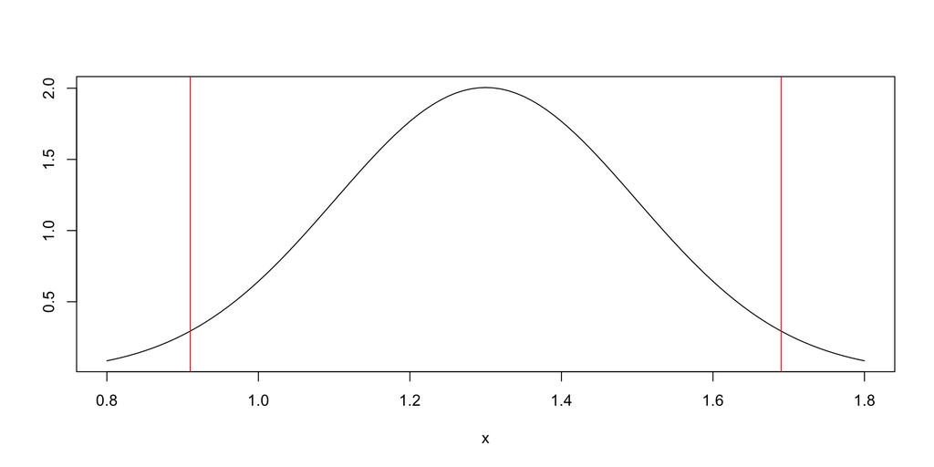

## Gamma Example

```r
gamma_fn <- function(x1, p1, x2, p2, alpha)
  x1*qgamma(p2,shape = alpha) - x2*qgamma(p1, shape = alpha)

param_gamma <- function(x1,x2,p1,p2,range) {
    alpha <- uniroot(function(a) gamma_fn(x1,p1,x2,p2,a),range)$root
    beta  <- x1 / qgamma(p1,alpha)
    c("alpha" = alpha, "beta" = beta)
}

param_gamma(x1=0.91, p1=0.025, x2=1.69, p2=0.975, range = c(1,100))
```

```
    alpha      beta
40.586498  0.031301
```

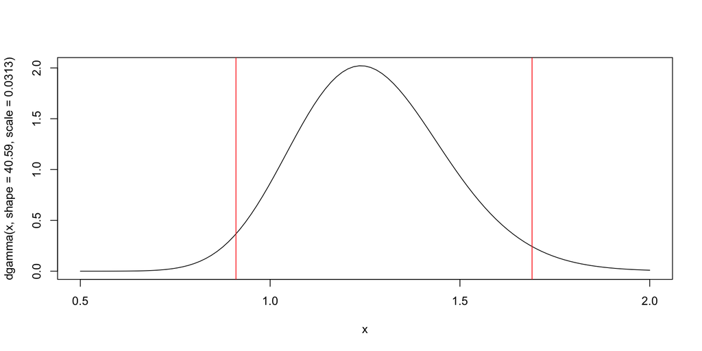

## General Optimization Technique

- General solution, requires cumulative distribution function (CDF), $F$.
- https://hwborchers.lima-city.de/Presents/ROptimSlides4.pdf for optimization tutorial in R

$$\min_{\vec{\theta} \in R}\,\, (F(x_1|\vec{\theta})-p_1)^2+(F(x_2|\vec{\theta})-p_2)^2$$

## Normal via Optim

- Expected 1.30000 0.19898
- **Not the right answer!**

```r
library(pracma)
norm <- function(x1, p1, x2, p2, mu, sigma)
 (pnorm(x1, mu, sigma)-p1)^2 +
 (pnorm(x2, mu, sigma)-p2)^2

fn <- function(x) norm(0.91, 0.025, 1.69, 0.975, x[1], x[2])

optim(c(0.5, 0.1),
      fn,
      gr = function(x) pracma::grad(fn, x),
      lower=c(-Inf, 1e-4),
      method = "L-BFGS-B",
      control=list(factr=1e-10, maxit=100))$par
```

```
[1] 1.0721 0.0001
```

## Normal via Optim

- Note that the function is on the probability scale.
- We have seen issues with probability before.
- Note the gradient of the tails.

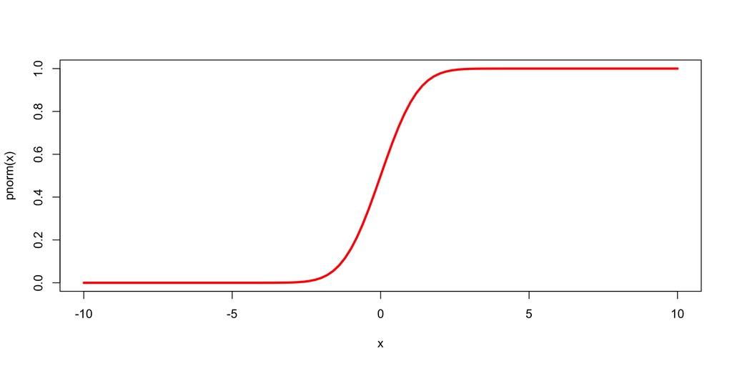

## Stable Optimization

- Analytically correct formula is not numerically stable.
- Transfinite scaling stabilizes optimization.
- For probabilities, this is the $\text{logit}(p)=\log \frac{p}{1-p}=\log p - \log (1-p)$.
- Tweaking parameters to converge can still happen.
- Example of theory versus practice.

$$\min_{\vec{\theta} \in R} \sum_{i \in 1,2}\,\, (\text{logit} (F(x_i|\vec{\theta}))-\text{logit} (p_i))^2$$

## Transfinite Example

```r
Tf <- function(x, mu, sigma) # Stable Logit for *any* distribution
    pnorm(x, mu, sigma, log=TRUE) -
    pnorm(x, mu, sigma, log=TRUE, lower.tail=FALSE)

norm <- function(x1, p1, x2, p2, mu, sigma)
 (Tf(x1, mu, sigma)-(log(p1)-log(1-p1)) )^2 +
 (Tf(x2, mu, sigma)-(log(p2)-log(1-p2)) )^2

fn <- function(x) norm(0.91, 0.025, 1.69, 0.975, x[1], x[2])

optim(c(0.5, 0.1),
      fn,
      gr = function(x) pracma::grad(fn, x),
      lower=c(-Inf, 1e-5),
      method = "L-BFGS-B",
      control=list(factr=1e-10, maxit=100))$par
```

```
[1] 1.30000 0.19898
```

## Summary on Distribution Fitting

- Use analytical formulas if they exist.
- Optimize on $\text{logit}$ scale.
- Again, avoid $\log$ on probabilities, use `log=TRUE`.
- Plot results for visual check.

# Copulas

## What is a Copula?

- The binding “glue” between correlated variables.

## Copulas and PSA Sampling

We typically draw PSA samples from the *marginal* distribution of each variable:

$$F_1(x_1), ..., F_d(x_d)$$

## Copulas and PSA Sampling

Copulas allow us to sample from the *joint* distribution:

$$F(x_1,...,x_d) = C \big ( F_1(x_1), ..., F_d(x_d) \big )$$

(This is a result of Sklar [1959].)

## Copulas and PSA Sampling

- Copula: a multivariate cumulative distribution function with uniform marginals.

Back to Website

Chhatwal, Jagpreet, Suren Jayasuriya, and Elamin H. Elbasha. 2016. “Changing Cycle Lengths in State-Transition Models: Challenges and Solutions.” *Medical Decision Making* 36 (8): 952–64. https://doi.org/10.1177/0272989X16656165.

Higham, Nicholas J. 2008. *Functions of Matrices: Theory and Computation*. SIAM.